# Analisi dei progetti di Kickstarter

22 Giugno 2018

## Introduzione

### Cos'è Kickstarter?

[figure not shown]

## Introduzione

### Cos'è Kickstarter?

Piattaforma di **crowdfunding** lanciata nel 2009 a Manhattan.

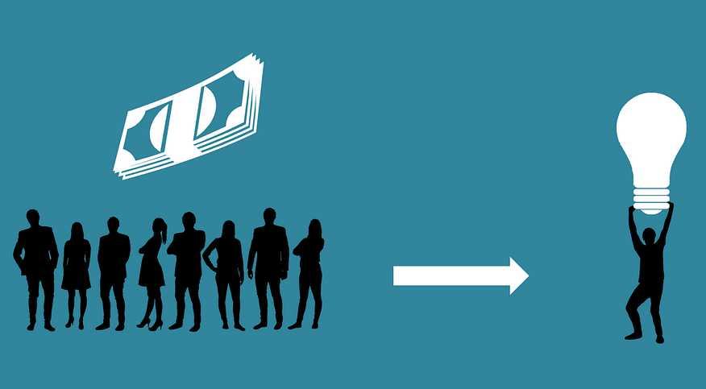

- Progetto creativo
  - data di scadenza
  - goal di finanziamenti
- Finanziamento collettivo
- Eventuale produzione e vendita

## Introduzione

Progetti creativi da tutto il mondo

[interactive chart not shown]

## Scopi principali

### *di questa analisi*

1. Esplorazione di un dataset
2. Analisi delle infomazioni
3. Modelli di previsione del successo

## Il dataset

### *Overview*

[figure not shown]

*www.kaggle.com*

formato csv

## Il dataset

### *Overview*

```
##  [1] "ID"               "name"             "category"
##  [4] "main_category"    "currency"         "deadline"
##  [7] "goal"             "launched"         "pledged"
## [10] "state"            "backers"          "country"
## [13] "usd_pledged_real" "usd_goal_real"
```

## Il dataset

### *Cleaning*

- Valori mancanti: Nomi

```
##               ID             name         category    main_category
##                0                4                0                0
##         currency         deadline             goal         launched
##                0                0                0                0
##          pledged            state          backers          country
##                0                0                0                0
## usd_pledged_real    usd_goal_real
##                0                0
```

## Il dataset

### *Cleaning*

- Valori errati: Date di lancio

```
## # A tibble: 378,657 x 2
##    name                                                launched
##    <chr>                                               <dttm>
##  1 Salt of the Earth: A Dead Sea Movie (Canceled)      1970-01-01 01:00:00
##  2 1st Super-Size Painting - Social Network Owned (Ca… 1970-01-01 01:00:00
##  3 "\"ICHOR\"  (Canceled)"                             1970-01-01 01:00:00
##  4 "Support Solo Theater! Help \"Ungrateful Daughter\… 1970-01-01 01:00:00
##  5 Help RIZ Make A Charity Album: 8 Songs, 8 Causes, … 1970-01-01 01:00:00
##  6 Identity Communications Infographic (Canceled)      1970-01-01 01:00:00
##  7 Student Auditions Music 2015                        1970-01-01 01:00:00
##  8 Grace Jones Does Not Give A F$#% T-Shirt (limited … 2009-04-21 21:02:48
##  9 CRYSTAL ANTLERS UNTITLED MOVIE                      2009-04-23 00:07:53
## 10 drawing for dollars                                 2009-04-24 21:52:03
## # ... with 378,647 more rows
```

## Analisi dei dati

### *Finanziamenti*

Intervallo temporale: 21/04/2009 - 02/01/2018

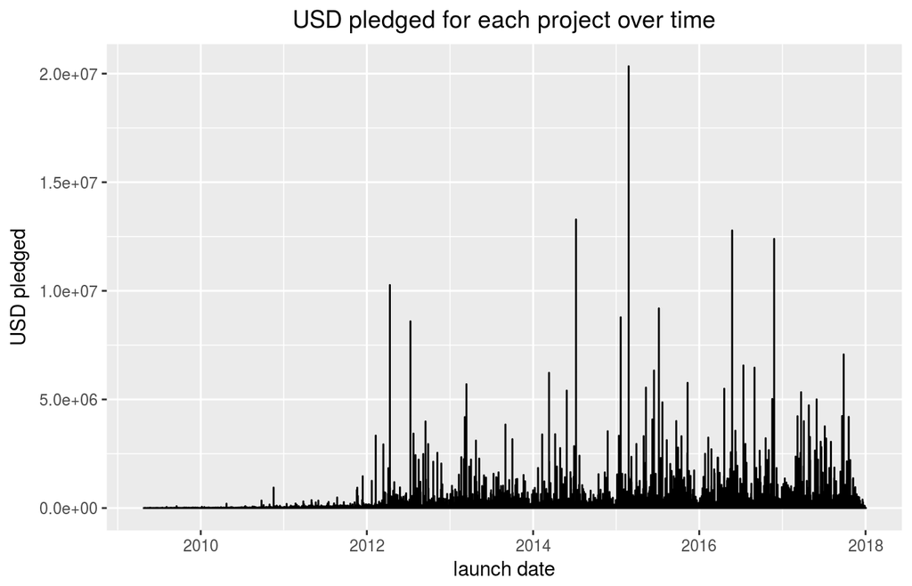

## Analisi dei dati

### *Finanziamenti*

Variabili di riferimento:

Denaro investito

```
## # A tibble: 69,488 x 3
##    currency  pledged usd_pledged_real
##    <chr>       <dbl>            <dbl>
##  1 GBP      94175.         121857.
##  2 AUD          1.00            0.810
##  3 NOK         48.0             6.29
##  4 CAD      48905.          42174.
##  5 GBP        112.            161.
##  6 GBP         21.0            31.1
##  7 AUD       2000.           1427.
##  8 CAD        592.            473.
##  9 EUR        137.            151.
## 10 CAD        700.            535.
## # ... with 69,478 more rows
```

Obbiettivo economico

```
## # A tibble: 69,494 x 5
##    currency   goal usd_goal_real usd_pledged_real state
##    <chr>     <dbl>         <dbl>            <dbl> <chr>
##  1 GBP       5000.        6470.        121857.    successful
##  2 AUD       2500.        2026.             0.810 failed
##  3 NOK        500.          65.6            6.29  failed
##  4 CAD      17757.       15313.         42174.    successful
##  5 GBP        100.         143.           161.    successful
##  6 GBP       3500.        5181.            31.1   failed
##  7 AUD       2000.        1427.          1427.    successful
##  8 CAD       3000.        2396.           473.    live
##  9 EUR      12000.       13202.           151.    failed
## 10 CAD      15000.       11466.           535.    canceled
## # ... with 69,484 more rows
```

## Analisi dei dati

### *Finanziamenti*

Come sono distribuiti i finanziamenti nei diversi anni?

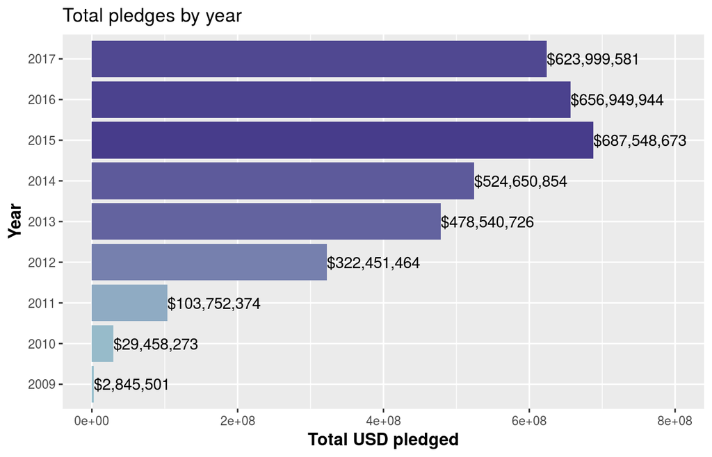

## Analisi dei dati

### *Finanziamenti*

Quali sono stati i progetti **più finanziati**?

```
## # A tibble: 10 x 4
##    year  name                               usd_pledged_real usd_goal_real
##    <chr> <chr>                              <chr>            <chr>
##  1 2009  Designing Obama                    $84,614          $65,000
##  2 2010  TikTok+LunaTik Multi-Touch Watch … $942,578         $15,000
##  3 2011  Elevation Dock: The Best Dock For… $1,464,707       $75,000
##  4 2012  Pebble: E-Paper Watch for iPhone … $10,266,846      $100,000
##  5 2013  The Veronica Mars Movie Project    $5,702,153       $2,000,000
##  6 2014  COOLEST COOLER: 21st Century Cool… $13,285,226      $50,000
##  7 2015  Pebble Time - Awesome Smartwatch,… $20,338,986      $500,000
##  8 2016  Pebble 2, Time 2 + All-New Pebble… $12,779,843      $1,000,000
##  9 2017  THE 7th CONTINENT – What Goes Up,… $7,072,757       $40,000
## 10 2018  The Prayer Chain - Shawl Double V… $10,847          $25,000
```

## Analisi dei dati

### *Finanziamenti*

I tre progetti con più finanziamenti nella storia di kickstarter:

[figure not shown]

**Pebble Time**

$20,338,986

## Analisi dei dati

### *Finanziamenti*

I tre progetti con più finanziamenti nella storia di kickstarter:

[figure not shown]

seguito da **Coolest Cooler**

$13,285,226

## Analisi dei dati

### *Finanziamenti*

I tre progetti con più finanziamenti nella storia di kickstarter:

[figure not shown]

e da **Pebble 2**

$12,779,843

## Analisi dei dati

### *Categorie*

- I progetti sono suddivisi in 15 categorie
- Ogni categoria presenta svariate sottocategorie

Ha senso utilizzare entrambe le informazioni?

[interactive chart not shown]

## Analisi dei dati

### *Categorie*

Sarà sufficiente analizzare le categorie principali

Quali sono le categorie **più frequenti**?

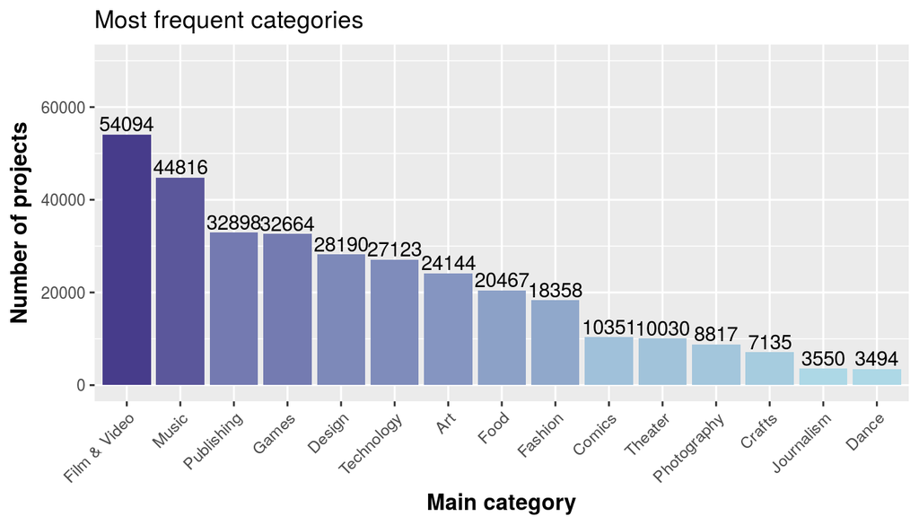

## Analisi dei dati

### *Categorie*

Prime 15 categorie in termini di **finanziamenti**

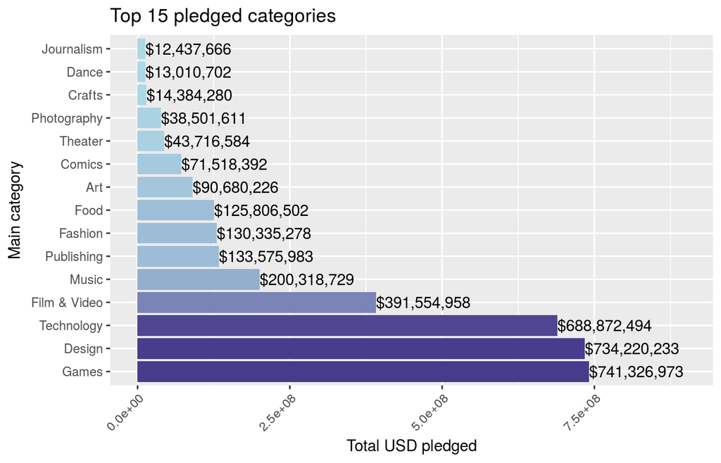

## Analisi dei dati

### *Successo*

- Quali sono i possibili **stati** di un progetto?

```
## [1] "failed"     "canceled"   "successful" "live"       "undefined"
## [6] "suspended"
```

- Come si distribuiscono le categorie in termini di successo?

[interactive chart not shown]

## Analisi dei dati

### *Successo*

Concentriamoci sugli stati di **successo** e **fallimento**.

## Analisi dei dati

### *Successo*

- **Differenze medie** tra i goal prefissati ed i finanziamenti raggiunti:

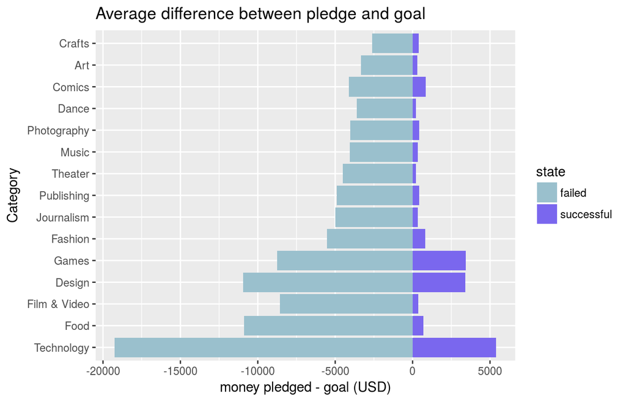

## Analisi dei dati

### *Successo*

- Percentuali di successo e fallimento **per categoria**:

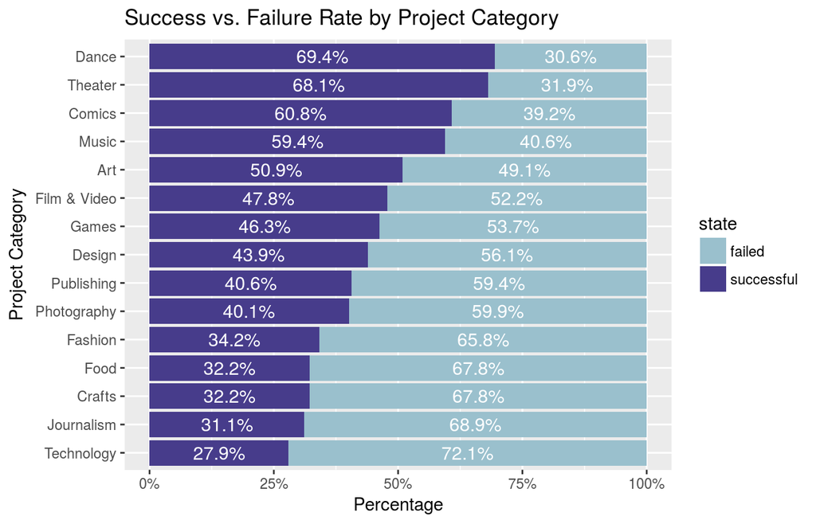

## Analisi dei dati

### *Successo*

- Percentuali di successo e fallimento **per stato**:

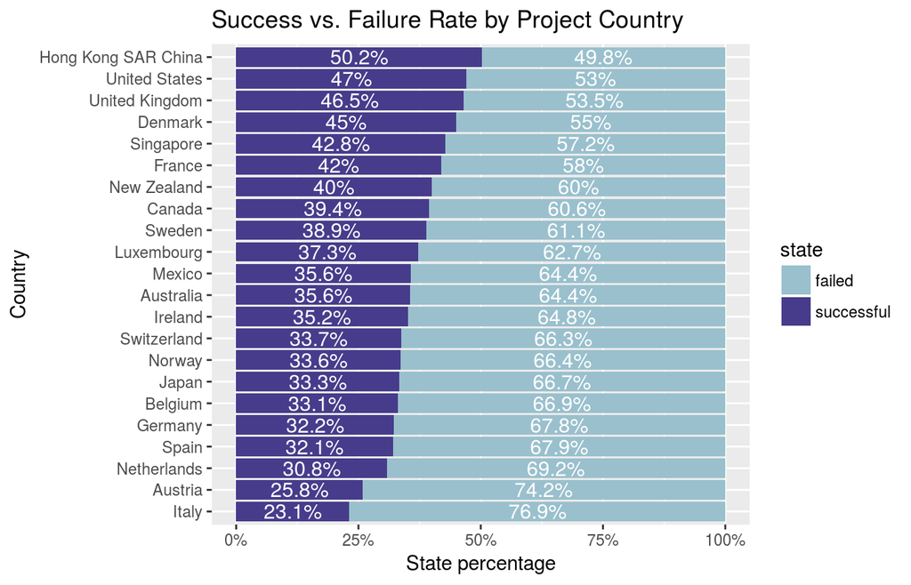

## Analisi dei dati

### *Successo*

Italia: **2243** vs Hong Kong: **555**

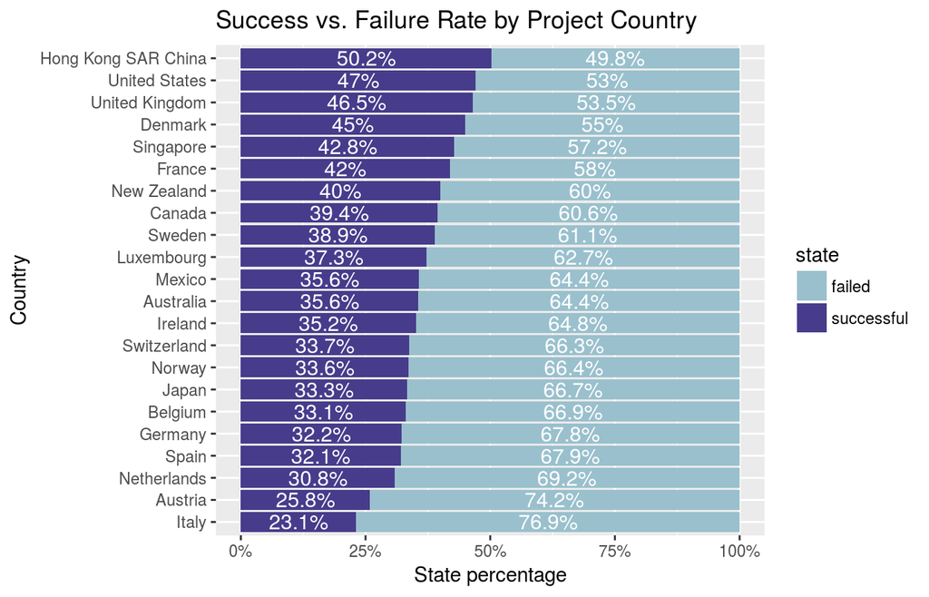

## Previsione del successo

### *Classificazione binaria*

Costruire due modelli di **previsione del successo**:

- Regressione logistica
- Random forest

**Suddivisione dei dati:**

training set 60% - test set 40%

## Previsione del successo

### *Regressione logistica*

Modello statistico per la classificazione binaria

- Costruzione del modello \[ logit(\text{p}) = \beta_0 + \beta_1 \, x_1 + \beta_2 \, x_2 + \dots + \beta_n \, x_n \] sul train set con la funzione `glm` e diverse combinazioni di variabili predittive.
- Scelta del modello con **AIC** più basso:

\[ AIC=2k-2ln(\hat{L}) \]

*k parametri stimati*

*\(\hat{L}\) valore massimo della funzione di verosimiglianza*

L'AIC misura la performance relativa di più modelli, penalizzando la loro complessità e massimizzando la verosimiglianza rispetto alle osservazioni.

## Previsione del successo

### *Regressione logistica*

Modello con minore AIC:

\[ logit(\text{p}) = \beta_0 + \beta_1 \, \text{country} + \beta_2 \, \text{goal} + \beta_3 \, \text{category} \]

```
## [1] "AIC 380881.255473576"
```

## Previsione del successo

### *Regressione logistica*

**Accuratezza**:

\[ \frac{TP+TN}{TP+TN+FP+FN} \]

Questo modello è in grado di prevedere il successo di un progetto con un'accuratezza del 57%

```
## [1] "Accuracy 0.575695783492313"
```

## Previsione del successo

### *Random Forest*

Algoritmo di supervised learning basato sul concetto di **albero di decisione**:

- nodo interno di un albero = variabile indipendente
- etichetta di un ramo = possibile valore di una variabile indipendente
- etichetta di una foglia = possibile valore della variabile dipendente

Costruisce molti alberi di decisione con diverse combinazioni di variabili indipendenti per **evitare overfitting**.

Problema: il consumo della RAM cresce linearmente con il numero di stimatori.

## Previsione del successo

### *Performance*

Confronto su training set di dimensione 8000.

**Accuratezza:**

```
## [1] "Regressione l.:  0.578833333333333"
```

```
## [1] "Random forest:  0.629166666666667"
```

**TPR** = sensitivity = TP/P

**FPR** = 1-specificity = 1-TN/N

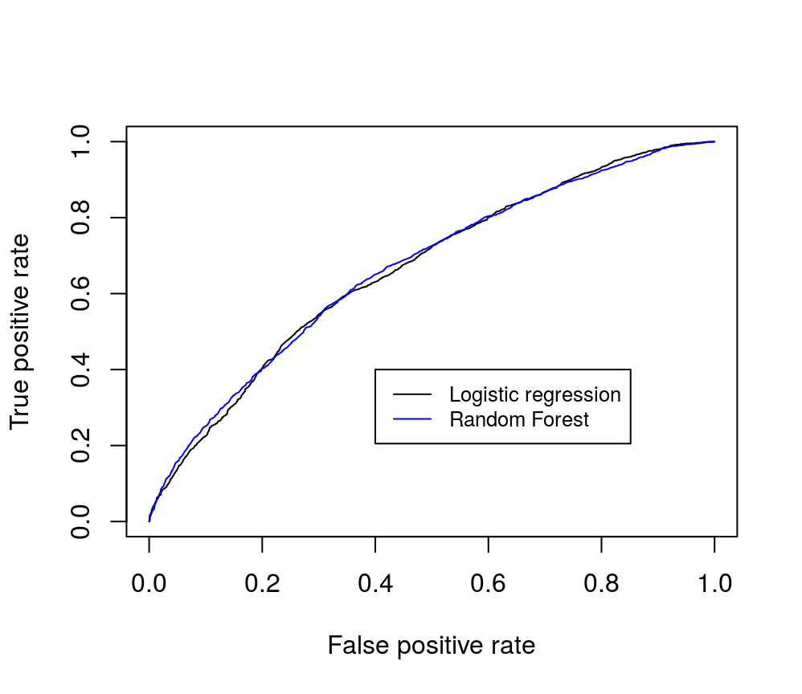

## Previsione del successo

### *Performance*

L'articolo

*"Predicting the success of Kickstarter campaigns", Nida Hussain, Kareem Kamel, Archana Radhakrishna, 2017, unpublished.*

raggiunge il 69% dell'accuratezza con la Regressione Logistica ed il 78% con il Random Forest.

## Conclusioni

- Esplorazione del dataset
  - Variabili di interesse
  - Valori mancanti o errati
- Analisi delle informazioni
  - Distribuzione dei progetti nel mondo
  - Relazioni tra finanziamenti, categorie e stati
  - Analisi del successo
- Modelli di previsione del successo
  - Regressione Logistica
  - Random Forest

Pacchetti utilizzati: `tidyverse`, `dplyr`, `ggplot2`, `highcharter`, `ROCR`, `randomForest`.

## Bibliografia

[1] https://www.kaggle.com/kemical/kickstarter-projects/data

[2] "Predicting the success of Kickstarter campaigns", Nida Hussain, Kareem Kamel, Archana Radhakrishna, 2017, unpublished.

[3] "An Introduction to Statistical Learning, with Applications in R", Gareth James, Daniela Witten, Trevor Hastie, Robert Tibshirani, Springer, 2014.

[4] "R for Data Science. Import, Tidy, Transform, Visualize, and Model Data", Hadley Wickham, Garrett Grolemund, O'Reilly, 2017.

[5] "Data Analysis and Graphics Using R", John Maindonald, W. John Braun, 2003.

[6] "Predicting the Success of Kickstarter Campaigns", Peter (Haochen) Zhou, 2017, unpublished.

## **Grazie per l'attenzione.**